# American Lobster: Where Will They Go?

January 27, 2026

## My Species: American Lobster

The **American Lobster** (*Homarus americanus*) is very important in the Gulf of Maine.

**Why I chose this species:**

- Most valuable fishery in New England
- Climate change is already affecting them
- Fishermen want to know: where will lobsters go?
- “Maine & Lobster” conversation

## My Question

**How will climate change affect American Lobster habitat?**

I used **Species Distribution Modeling (SDM)** to answer this.

## Step 1: Get the Data

I downloaded **209,167** lobster records from OBIS.

After cleaning (removing missing values, filtering by year), I kept **104,630** good quality records (Some had missing dates.Some had missing individual counts. Some were outside the Brickman model area. Some were before 1970 )

## Step 2: Where Are the Lobsters?

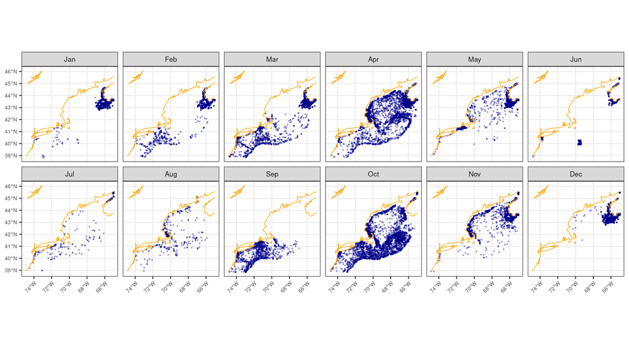

## Step 3: What Environment Do Lobsters Like?

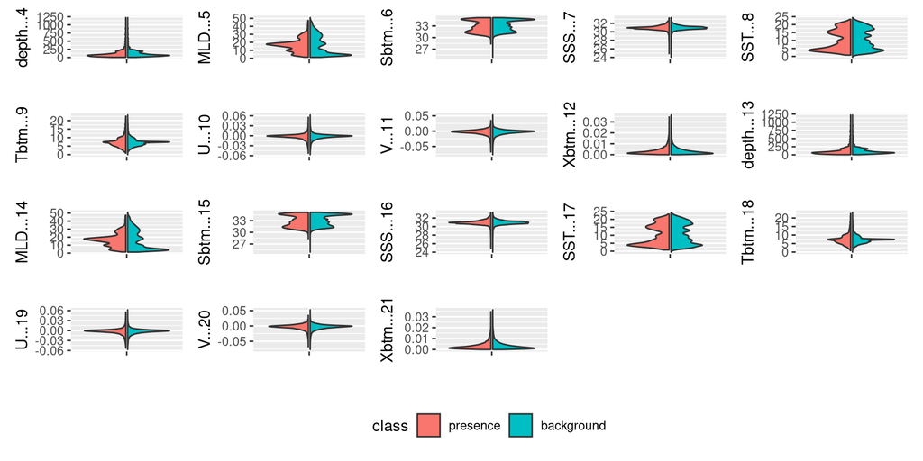

## What Lobsters Prefer

Based on the data:

| Factor | What Lobsters Like |
| --- | --- |
| **Depth** | Shallow water (< 250m) |
| **Bottom Temp** | Cool (5-10°C) |
| **Surface Temp** | Not too warm |

Lobsters avoid deep water and very warm temperatures!

## Step 4: Train the Model

I trained 4 models and compared their confusion matrices:

| Model | Accuracy | Found Lobsters? | Problem |
| --- | --- | --- | --- |
| GLM | 85.4% | 0 out of 1244 | Predicts all “no lobster” |
| Boosted Trees | 85.4% | 0 out of 1244 | Predicts all “no lobster” |
| Random Forest | 84.9% | 2 out of 1244 | Almost all “no lobster” |
| **MaxEnt** | 57.2% | **1033 out of 1244** | **Actually finds lobsters!** |

## Why I Chose MaxEnt

- Other models have higher accuracy BUT they cheat!
- They just say “no lobster everywhere” (easy to be right most of the time)
- **MaxEnt correctly identifies 83% of lobster locations**
- For species distribution, finding presence is more important!

## Step 5: Present Day Prediction

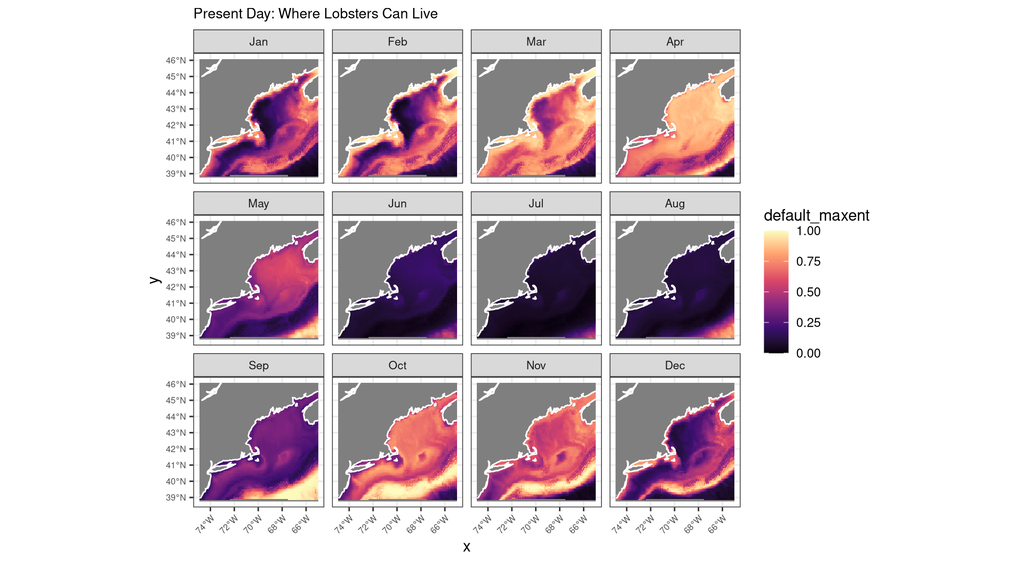

## What the Present Map Shows

This matches real lobster behavior!

## Step 6: Future Prediction (RCP 8.5, Year 2075)

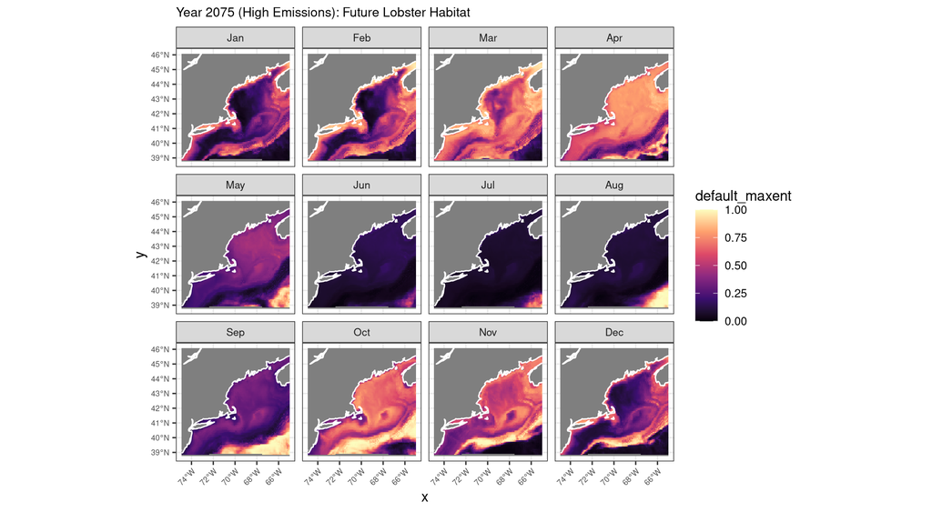

## Compare: Now vs 2075

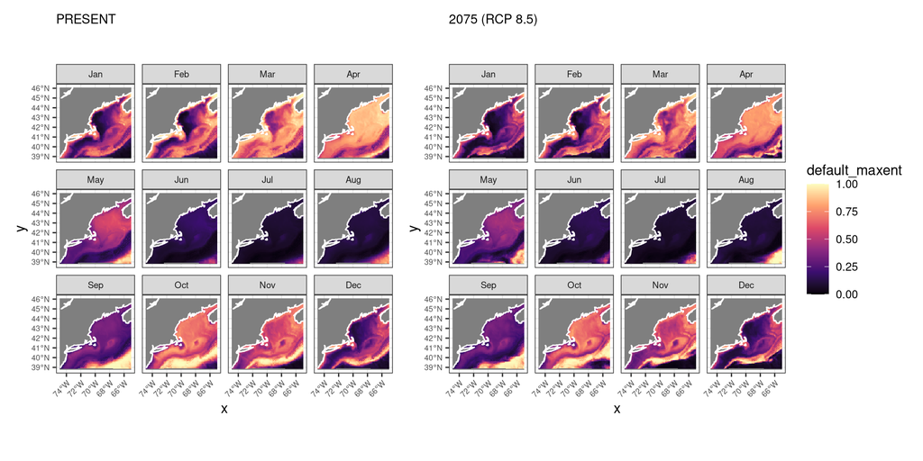

## Key Differences I Found

**Looking at Summer (May-Aug):**

| Present | 2075 |
| --- | --- |
| Some suitable habitat | Less suitable habitat |
| Moderate stress | More thermal stress |

**The pattern is similar because depth doesn’t change, but temperature does!**

## What Does This Mean?

**For Lobsters:**

**For Fishermen:**

- Fishing areas may shift north
- May need to adapt

## Summary

| Step | What I Did |
| --- | --- |
| 1 | Got data from OBIS |
| 2 | Cleaned the data |
| 3 | Found what lobsters like |
| 4 | Trained MaxEnt model |
| 5 | Predicted present habitat |
| 6 | Predicted future (2075) |

## Main Finding

**Climate change will reduce summer habitat for American Lobsters.**

## Thank You!

**Questions?**

*JP297Dj: Ocean Forecasting - AI, Ecology, and Data Justice*

*Colby College, January 27, 2026*